# data_analyis

**Learning Outcomes**

1. Pandas Introductions.
2. Series and Dataframe Pandas importnat data structures.
3. Loading Data into dataframes
4. Manipulating the data the Dataframe.
5. Dealing with null values.

**Pandas** is most commonly used Python libaray used for Loading and manupulating different structured data from csv , excel or tsv file formats.

# Importing Pandas into Python

```python
import pandas as pd  #This Line will import pandas into your Python Program
```

Primary Data Structure of Pandas

1. Series
2. DataFrame

Series is a one-dimensional labeled array capable of holding data of any type (integer, string, float, python objects, etc.).

Data frame is a two-dimensional data structure, i.e., data is aligned in a tabular fashion in rows and columns. Pandas DataFrame consists of three principal components, the data, rows, and columns.

```python
city_name =  ['Delhi' , 'Mumbai' , 'Rahuri']  # This is Python List which contain name of the cities
print(type(city_name))
print(city_name)
```

```
<class 'list'>
['Delhi', 'Mumbai', 'Rahuri']
```

# Now Creating a Series from List

```python
city_series = pd.Series(city_name)
print(city_series)
```

```
0     Delhi
1    Mumbai
2    Rahuri
dtype: object
```

```python
print(type(city_series))
```

```
<class 'pandas.core.series.Series'>
```

```python
city_dataframe = pd.DataFrame(city_name)
```

```python
print(city_dataframe)
```

```
        0
0   Delhi
1  Mumbai
2  Rahuri
```

# Difference Between Series and Data Frame

```python
print(city_series.shape)
```

```
(3,)
```

```python
print(city_dataframe.shape)
```

```
(3, 1)
```

```python
print(city_dataframe[0])
```

```
0     Delhi
1    Mumbai
2    Rahuri
Name: 0, dtype: object
```

```python
print(city_series[0])
```

```
Delhi
```

# Loading Data from CSV

```python
data = pd.read_csv('/content/rainfall.csv')
```

```python
print(type(data))
```

```
<class 'pandas.core.frame.DataFrame'>
```

```python
print(data)
```

```
                    SUBDIVISION  YEAR   JAN  ...  Mar-May  Jun-Sep  Oct-Dec
0     ANDAMAN & NICOBAR ISLANDS  1901  49.2  ...    560.3   1696.3    980.3
1     ANDAMAN & NICOBAR ISLANDS  1902   0.0  ...    458.3   2185.9    716.7
2     ANDAMAN & NICOBAR ISLANDS  1903  12.7  ...    236.1   1874.0    690.6
3     ANDAMAN & NICOBAR ISLANDS  1904   9.4  ...    506.9   1977.6    571.0
4     ANDAMAN & NICOBAR ISLANDS  1905   1.3  ...    309.7   1624.9    630.8
...                         ...   ...   ...  ...      ...      ...      ...
4111                LAKSHADWEEP  2011   5.1  ...    196.2   1013.0    316.6
4112                LAKSHADWEEP  2012  19.2  ...     99.6   1119.5    167.1
4113                LAKSHADWEEP  2013  26.2  ...    131.1   1057.0    177.6
4114                LAKSHADWEEP  2014  53.2  ...     76.7    958.5    290.5
4115                LAKSHADWEEP  2015   2.2  ...    223.9    860.9    555.4

[4116 rows x 19 columns]
```

```python
# print(data.head())
data.head()
```

|  | SUBDIVISION | YEAR | JAN | FEB | MAR | APR | MAY | JUN | JUL | AUG | SEP | OCT | NOV | DEC | ANNUAL | Jan-Feb | Mar-May | Jun-Sep | Oct-Dec |
| --- | --- | --- | --- | --- | --- | --- | --- | --- | --- | --- | --- | --- | --- | --- | --- | --- | --- | --- | --- |
| 0 | ANDAMAN & NICOBAR ISLANDS | 1901 | 49.2 | 87.1 | 29.2 | 2.3 | 528.8 | 517.5 | 365.1 | 481.1 | 332.6 | 388.5 | 558.2 | 33.6 | 3373.2 | 136.3 | 560.3 | 1696.3 | 980.3 |
| 1 | ANDAMAN & NICOBAR ISLANDS | 1902 | 0.0 | 159.8 | 12.2 | 0.0 | 446.1 | 537.1 | 228.9 | 753.7 | 666.2 | 197.2 | 359.0 | 160.5 | 3520.7 | 159.8 | 458.3 | 2185.9 | 716.7 |
| 2 | ANDAMAN & NICOBAR ISLANDS | 1903 | 12.7 | 144.0 | 0.0 | 1.0 | 235.1 | 479.9 | 728.4 | 326.7 | 339.0 | 181.2 | 284.4 | 225.0 | 2957.4 | 156.7 | 236.1 | 1874.0 | 690.6 |
| 3 | ANDAMAN & NICOBAR ISLANDS | 1904 | 9.4 | 14.7 | 0.0 | 202.4 | 304.5 | 495.1 | 502.0 | 160.1 | 820.4 | 222.2 | 308.7 | 40.1 | 3079.6 | 24.1 | 506.9 | 1977.6 | 571.0 |
| 4 | ANDAMAN & NICOBAR ISLANDS | 1905 | 1.3 | 0.0 | 3.3 | 26.9 | 279.5 | 628.7 | 368.7 | 330.5 | 297.0 | 260.7 | 25.4 | 344.7 | 2566.7 | 1.3 | 309.7 | 1624.9 | 630.8 |

```python
print(data.columns)
col_name = list(data.columns)
print(col_name)
```

```
Index(['SUBDIVISION', 'YEAR', 'JAN', 'FEB', 'MAR', 'APR', 'MAY', 'JUN', 'JUL',
       'AUG', 'SEP', 'OCT', 'NOV', 'DEC', 'ANNUAL', 'Jan-Feb', 'Mar-May',
       'Jun-Sep', 'Oct-Dec'],
      dtype='object')
['SUBDIVISION', 'YEAR', 'JAN', 'FEB', 'MAR', 'APR', 'MAY', 'JUN', 'JUL', 'AUG', 'SEP', 'OCT', 'NOV', 'DEC', 'ANNUAL', 'Jan-Feb', 'Mar-May', 'Jun-Sep', 'Oct-Dec']
```

```python
print(data.tail(10))
```

```
      SUBDIVISION  YEAR   JAN   FEB  ...  Jan-Feb  Mar-May  Jun-Sep  Oct-Dec
4106  LAKSHADWEEP  2006  20.1   0.0  ...     20.1    361.2    928.4    288.9
4107  LAKSHADWEEP  2007   2.5   4.2  ...      6.7    188.6   1753.0    413.3
4108  LAKSHADWEEP  2008   5.5  19.8  ...     25.3    316.9    934.0    450.6
4109  LAKSHADWEEP  2009   4.7   1.5  ...      6.2    180.3    997.7    385.9
4110  LAKSHADWEEP  2010  18.8   0.0  ...     18.8    115.8   1152.2    438.4
4111  LAKSHADWEEP  2011   5.1   2.8  ...      7.9    196.2   1013.0    316.6
4112  LAKSHADWEEP  2012  19.2   0.1  ...     19.3     99.6   1119.5    167.1
4113  LAKSHADWEEP  2013  26.2  34.4  ...     60.6    131.1   1057.0    177.6
4114  LAKSHADWEEP  2014  53.2  16.1  ...     69.3     76.7    958.5    290.5
4115  LAKSHADWEEP  2015   2.2   0.5  ...      2.7    223.9    860.9    555.4

[10 rows x 19 columns]
```

```python
print(data.shape)
```

```
(4116, 19)
```

# Exploration of Data

```python
print(data.info())
```

```
<class 'pandas.core.frame.DataFrame'>
RangeIndex: 4116 entries, 0 to 4115
Data columns (total 19 columns):
 #   Column       Non-Null Count  Dtype
---  ------       --------------  -----
 0   SUBDIVISION  4116 non-null   object
 1   YEAR         4116 non-null   int64
 2   JAN          4112 non-null   float64
 3   FEB          4113 non-null   float64
 4   MAR          4110 non-null   float64
 5   APR          4112 non-null   float64
 6   MAY          4113 non-null   float64
 7   JUN          4111 non-null   float64
 8   JUL          4109 non-null   float64
 9   AUG          4112 non-null   float64
 10  SEP          4110 non-null   float64
 11  OCT          4109 non-null   float64
 12  NOV          4105 non-null   float64
 13  DEC          4106 non-null   float64
 14  ANNUAL       4090 non-null   float64
 15  Jan-Feb      4110 non-null   float64
 16  Mar-May      4107 non-null   float64
 17  Jun-Sep      4106 non-null   float64
 18  Oct-Dec      4103 non-null   float64
dtypes: float64(17), int64(1), object(1)
memory usage: 611.1+ KB
None
```

```python
print(data.describe())
```

```
              YEAR          JAN  ...      Jun-Sep      Oct-Dec
count  4116.000000  4112.000000  ...  4106.000000  4103.000000
mean   1958.218659    18.957320  ...  1064.724769   154.100487
std      33.140898    33.585371  ...   707.741531   166.942660
min    1901.000000     0.000000  ...    57.400000     0.000000
25%    1930.000000     0.600000  ...   573.850000    34.200000
50%    1958.000000     6.000000  ...   881.100000    98.200000
75%    1987.000000    22.200000  ...  1288.175000   213.500000
max    2015.000000   583.700000  ...  4536.900000  1252.500000

[8 rows x 18 columns]
```

```python
data['JAN'].describe()
```

```
count    4112.000000
mean       18.957320
std        33.585371
min         0.000000
25%         0.600000
50%         6.000000
75%        22.200000
max       583.700000
Name: JAN, dtype: float64
```

```python
data['MAY'].describe()
```

```
count    4113.000000
mean       85.745417
std       123.234904
min         0.000000
25%         8.600000
50%        36.600000
75%        97.200000
max      1168.600000
Name: MAY, dtype: float64
```

```python
data['SUBDIVISION'].describe()
```

```
count      4116
unique       36
top       BIHAR
freq        115
Name: SUBDIVISION, dtype: object
```

```python
data['SUBDIVISION'].unique()
```

```
array(['ANDAMAN & NICOBAR ISLANDS', 'ARUNACHAL PRADESH',
       'ASSAM & MEGHALAYA', 'NAGA MANI MIZO TRIPURA',
       'SUB HIMALAYAN WEST BENGAL & SIKKIM', 'GANGETIC WEST BENGAL',
       'ORISSA', 'JHARKHAND', 'BIHAR', 'EAST UTTAR PRADESH',
       'WEST UTTAR PRADESH', 'UTTARAKHAND', 'HARYANA DELHI & CHANDIGARH',
       'PUNJAB', 'HIMACHAL PRADESH', 'JAMMU & KASHMIR', 'WEST RAJASTHAN',
       'EAST RAJASTHAN', 'WEST MADHYA PRADESH', 'EAST MADHYA PRADESH',
       'GUJARAT REGION', 'SAURASHTRA & KUTCH', 'KONKAN & GOA',
       'MADHYA MAHARASHTRA', 'MATATHWADA', 'VIDARBHA', 'CHHATTISGARH',
       'COASTAL ANDHRA PRADESH', 'TELANGANA', 'RAYALSEEMA', 'TAMIL NADU',
       'COASTAL KARNATAKA', 'NORTH INTERIOR KARNATAKA',
       'SOUTH INTERIOR KARNATAKA', 'KERALA', 'LAKSHADWEEP'], dtype=object)
```

```python
punjab_df = data[data['SUBDIVISION'] == "PUNJAB"]
```

```python
punjab_df.head()
```

|  | SUBDIVISION | YEAR | JAN | FEB | MAR | APR | MAY | JUN | JUL | AUG | SEP | OCT | NOV | DEC | ANNUAL | Jan-Feb | Mar-May | Jun-Sep | Oct-Dec |
| --- | --- | --- | --- | --- | --- | --- | --- | --- | --- | --- | --- | --- | --- | --- | --- | --- | --- | --- | --- |
| 1472 | PUNJAB | 1901 | 55.7 | 50.1 | 25.2 | 2.1 | 25.2 | 10.4 | 178.2 | 145.0 | 24.4 | 3.7 | 0.0 | 3.3 | 523.5 | 105.9 | 52.5 | 358.1 | 7.0 |
| 1473 | PUNJAB | 1902 | 0.0 | 0.8 | 9.9 | 10.9 | 29.6 | 49.9 | 125.6 | 94.9 | 67.2 | 9.0 | 0.0 | 0.1 | 398.0 | 0.8 | 50.4 | 337.7 | 9.1 |
| 1474 | PUNJAB | 1903 | 29.5 | 0.5 | 45.0 | 1.3 | 9.2 | 5.2 | 212.2 | 119.1 | 132.5 | 6.9 | 0.0 | 9.5 | 571.0 | 29.9 | 55.5 | 469.1 | 16.4 |
| 1475 | PUNJAB | 1904 | 24.2 | 1.7 | 87.8 | 1.2 | 13.8 | 22.0 | 59.9 | 124.0 | 73.8 | 7.4 | 9.8 | 25.9 | 451.5 | 25.9 | 102.9 | 279.7 | 43.1 |
| 1476 | PUNJAB | 1905 | 53.0 | 40.3 | 24.3 | 0.5 | 2.2 | 19.2 | 122.6 | 50.3 | 111.1 | 1.2 | 0.0 | 9.4 | 434.3 | 93.3 | 27.0 | 303.2 | 10.7 |

```python
punjab_df.info()
```

```
<class 'pandas.core.frame.DataFrame'>
Int64Index: 115 entries, 1472 to 1586
Data columns (total 19 columns):
 #   Column       Non-Null Count  Dtype
---  ------       --------------  -----
 0   SUBDIVISION  115 non-null    object
 1   YEAR         115 non-null    int64
 2   JAN          115 non-null    float64
 3   FEB          115 non-null    float64
 4   MAR          115 non-null    float64
 5   APR          115 non-null    float64
 6   MAY          115 non-null    float64
 7   JUN          115 non-null    float64
 8   JUL          115 non-null    float64
 9   AUG          115 non-null    float64
 10  SEP          115 non-null    float64
 11  OCT          115 non-null    float64
 12  NOV          115 non-null    float64
 13  DEC          115 non-null    float64
 14  ANNUAL       115 non-null    float64
 15  Jan-Feb      115 non-null    float64
 16  Mar-May      115 non-null    float64
 17  Jun-Sep      115 non-null    float64
 18  Oct-Dec      115 non-null    float64
dtypes: float64(17), int64(1), object(1)
memory usage: 18.0+ KB
```

```python
punjab_df['JAN'].describe()
```

```
count    115.000000
mean      25.246087
std       22.306656
min        0.000000
25%        7.250000
50%       21.600000
75%       36.100000
max      112.100000
Name: JAN, dtype: float64
```

# Dealing with Null / Missing Values

1. Python represent missing values as nan or null for missing value.
2. Most of the scikit-learn will give you error if your model contains missing value.

To Support handling misssing values Pandas support betow function:

1. isnull(): Generate a boolean mask indicating missing values
2. notnull(): Opposite of isnull()
3. dropna(): Return a filtered version of the data
4. fillna(): Return a copy of the data with missing values filled or imputed.

```python
percent_missing = punjab_df.isnull().sum() * 100 / len(punjab_df)
percent_missing
```

```
SUBDIVISION    0.0
YEAR           0.0
JAN            0.0
FEB            0.0
MAR            0.0
APR            0.0
MAY            0.0
JUN            0.0
JUL            0.0
AUG            0.0
SEP            0.0
OCT            0.0
NOV            0.0
DEC            0.0
ANNUAL         0.0
Jan-Feb        0.0
Mar-May        0.0
Jun-Sep        0.0
Oct-Dec        0.0
dtype: float64
```

How to handle Missing Value columns

1. First approach is to simply drop columns with Null values.
2. Filling missing values.
3. Predicting Missing values

When to drop columns and when to fill missing values. Although there is no rule regarding that. But general guideline which i personally follow is more that 30 percent of data is missing then i will simply drop the columns else i will .try to fill missing values.

```python
df= pd.read_csv('/content/titanic.csv')
df.head()
```

|  | PassengerId | Survived | Pclass | Name | Sex | Age | SibSp | Parch | Ticket | Fare | Cabin | Embarked | WikiId | Name_wiki | Age_wiki | Hometown | Boarded | Destination | Lifeboat | Body | Class |
| --- | --- | --- | --- | --- | --- | --- | --- | --- | --- | --- | --- | --- | --- | --- | --- | --- | --- | --- | --- | --- | --- |
| 0 | 1 | 0.0 | 3 | Braund, Mr. Owen Harris | male | 22.0 | 1 | 0 | A/5 21171 | 7.2500 | NaN | S | 691.0 | Braund, Mr. Owen Harris | 22.0 | Bridgerule, Devon, England | Southampton | Qu'Appelle Valley, Saskatchewan, Canada | NaN | NaN | 3.0 |
| 1 | 2 | 1.0 | 1 | Cumings, Mrs. John Bradley (Florence Briggs Th... | female | 38.0 | 1 | 0 | PC 17599 | 71.2833 | C85 | C | 90.0 | Cumings, Mrs. Florence Briggs (née Thayer) | 35.0 | New York, New York, US | Cherbourg | New York, New York, US | 4 | NaN | 1.0 |
| 2 | 3 | 1.0 | 3 | Heikkinen, Miss. Laina | female | 26.0 | 0 | 0 | STON/O2. 3101282 | 7.9250 | NaN | S | 865.0 | Heikkinen, Miss Laina | 26.0 | Jyväskylä, Finland | Southampton | New York City | 14? | NaN | 3.0 |
| 3 | 4 | 1.0 | 1 | Futrelle, Mrs. Jacques Heath (Lily May Peel) | female | 35.0 | 1 | 0 | 113803 | 53.1000 | C123 | S | 127.0 | Futrelle, Mrs. Lily May (née Peel) | 35.0 | Scituate, Massachusetts, US | Southampton | Scituate, Massachusetts, US | D | NaN | 1.0 |
| 4 | 5 | 0.0 | 3 | Allen, Mr. William Henry | male | 35.0 | 0 | 0 | 373450 | 8.0500 | NaN | S | 627.0 | Allen, Mr. William Henry | 35.0 | Birmingham, West Midlands, England | Southampton | New York City | NaN | NaN | 3.0 |

```python
percent_missing = df.isnull().sum() * 100 / len(df)
percent_missing
```

```
PassengerId     0.000000
Survived        0.000000
Pclass          0.000000
Name            0.000000
Sex             0.000000
Age            19.865320
SibSp           0.000000
Parch           0.000000
Ticket          0.000000
Fare            0.000000
Cabin          77.104377
Embarked        0.224467
WikiId          0.224467
Name_wiki       0.224467
Age_wiki        0.448934
Hometown        0.224467
Boarded         0.224467
Destination     0.224467
Lifeboat       61.279461
Body           90.235690
Class           0.224467
dtype: float64
```

```python
# Drop columns more than 30% of missing data
col_to_drop = ['Cabin' ,'Lifeboat'  , 'Body']
df= df.drop(col_to_drop , axis=1)
```

```python
df.columns
```

```
Index(['PassengerId', 'Survived', 'Pclass', 'Name', 'Sex', 'Age', 'SibSp',
       'Parch', 'Ticket', 'Fare', 'Embarked', 'WikiId', 'Name_wiki',
       'Age_wiki', 'Hometown', 'Boarded', 'Destination', 'Class'],
      dtype='object')
```

```python
# Filling Null values
df.info()
```

```
<class 'pandas.core.frame.DataFrame'>
RangeIndex: 891 entries, 0 to 890
Data columns (total 18 columns):
 #   Column       Non-Null Count  Dtype
---  ------       --------------  -----
 0   PassengerId  891 non-null    int64
 1   Survived     891 non-null    float64
 2   Pclass       891 non-null    int64
 3   Name         891 non-null    object
 4   Sex          891 non-null    object
 5   Age          714 non-null    float64
 6   SibSp        891 non-null    int64
 7   Parch        891 non-null    int64
 8   Ticket       891 non-null    object
 9   Fare         891 non-null    float64
 10  Embarked     889 non-null    object
 11  WikiId       889 non-null    float64
 12  Name_wiki    889 non-null    object
 13  Age_wiki     887 non-null    float64
 14  Hometown     889 non-null    object
 15  Boarded      889 non-null    object
 16  Destination  889 non-null    object
 17  Class        889 non-null    float64
dtypes: float64(6), int64(4), object(8)
memory usage: 125.4+ KB
```

```python
# df['Age'].mean()
df['Age'].describe()
```

```
count    714.000000
mean      29.699118
std       14.526497
min        0.420000
25%       20.125000
50%       28.000000
75%       38.000000
max       80.000000
Name: Age, dtype: float64
```

```python
# Now filling Age with mean value
df['Age'].fillna(df['Age'].mean() , inplace = True)
```

```python
percent_missing = df.isnull().sum() * 100 / len(df)
percent_missing
```

```
PassengerId    0.000000
Survived       0.000000
Pclass         0.000000
Name           0.000000
Sex            0.000000
Age            0.000000
SibSp          0.000000
Parch          0.000000
Ticket         0.000000
Fare           0.000000
Embarked       0.224467
WikiId         0.224467
Name_wiki      0.224467
Age_wiki       0.448934
Hometown       0.224467
Boarded        0.224467
Destination    0.224467
Class          0.224467
dtype: float64
```

Excercise : If the sex is Male , fill age with mean of male ,for female fill mean of female.

```python
df['Embarked'].unique()
# Embarked is categorical value . so we can replace nan with MODE
```

```
array(['S', 'C', 'Q', nan], dtype=object)
```

```python
df['Embarked'].mode()
```

```
0    S
dtype: object
```

```python
df['Embarked'].fillna(df['Embarked'].mode()[0] , inplace = True)
```

```python
percent_missing = df.isnull().sum() * 100 / len(df)
percent_missing
```

```
PassengerId    0.000000
Survived       0.000000
Pclass         0.000000
Name           0.000000
Sex            0.000000
Age            0.000000
SibSp          0.000000
Parch          0.000000
Ticket         0.000000
Fare           0.000000
Embarked       0.000000
WikiId         0.224467
Name_wiki      0.224467
Age_wiki       0.448934
Hometown       0.224467
Boarded        0.224467
Destination    0.224467
Class          0.224467
dtype: float64
```

Excercise :Fill nan values for other columns.

# Highest Rainfall Year

```python
top_yr_punjab = punjab_df.nlargest(5,'ANNUAL')
```

```python
top_yr_punjab
```

|  | SUBDIVISION | YEAR | JAN | FEB | MAR | APR | MAY | JUN | JUL | AUG | SEP | OCT | NOV | DEC | ANNUAL | Jan-Feb | Mar-May | Jun-Sep | Oct-Dec |
| --- | --- | --- | --- | --- | --- | --- | --- | --- | --- | --- | --- | --- | --- | --- | --- | --- | --- | --- | --- |
| 1559 | PUNJAB | 1988 | 5.0 | 22.5 | 86.4 | 3.3 | 3.6 | 42.7 | 356.1 | 234.3 | 434.1 | 0.4 | 0.7 | 33.5 | 1222.6 | 27.5 | 93.3 | 1067.2 | 34.6 |
| 1488 | PUNJAB | 1917 | 6.5 | 3.1 | 12.5 | 71.9 | 31.3 | 82.6 | 172.4 | 211.4 | 369.1 | 156.5 | 0.0 | 9.4 | 1126.7 | 9.6 | 115.7 | 835.5 | 165.9 |
| 1521 | PUNJAB | 1950 | 53.1 | 25.4 | 50.1 | 2.4 | 8.1 | 14.1 | 209.2 | 232.3 | 396.8 | 0.4 | 0.0 | 0.1 | 992.0 | 78.5 | 60.5 | 852.4 | 0.6 |
| 1526 | PUNJAB | 1955 | 33.0 | 3.6 | 24.9 | 20.5 | 18.6 | 38.0 | 148.7 | 169.7 | 144.2 | 370.3 | 0.0 | 2.6 | 973.9 | 36.5 | 64.0 | 500.6 | 372.8 |
| 1513 | PUNJAB | 1942 | 27.2 | 57.2 | 15.4 | 19.6 | 13.4 | 52.4 | 253.3 | 256.4 | 131.7 | 5.1 | 0.0 | 39.8 | 871.6 | 84.4 | 48.4 | 693.9 | 44.9 |

# Lowest Rainfall Year

```python
low_yr_punjab =punjab_df.nsmallest(5 ,'ANNUAL')
```

```python
punjab_df['ANNUAL'].mean()
```

```
593.5356521739129
```

```python
low_yr_punjab
```

|  | SUBDIVISION | YEAR | JAN | FEB | MAR | APR | MAY | JUN | JUL | AUG | SEP | OCT | NOV | DEC | ANNUAL | Jan-Feb | Mar-May | Jun-Sep | Oct-Dec |
| --- | --- | --- | --- | --- | --- | --- | --- | --- | --- | --- | --- | --- | --- | --- | --- | --- | --- | --- | --- |
| 1573 | PUNJAB | 2002 | 2.4 | 6.6 | 6.8 | 3.3 | 20.8 | 24.7 | 50.4 | 58.4 | 95.0 | 2.6 | 0.0 | 3.7 | 274.7 | 9.0 | 31.0 | 228.4 | 6.3 |
| 1489 | PUNJAB | 1918 | 3.1 | 1.2 | 61.4 | 38.5 | 0.6 | 31.9 | 38.7 | 140.5 | 15.5 | 0.2 | 3.5 | 4.5 | 339.6 | 4.4 | 100.5 | 226.5 | 8.3 |
| 1575 | PUNJAB | 2004 | 32.4 | 5.7 | 0.0 | 15.5 | 27.2 | 48.8 | 52.1 | 124.2 | 8.9 | 31.2 | 0.8 | 5.0 | 351.7 | 38.0 | 42.7 | 234.0 | 37.0 |
| 1545 | PUNJAB | 1974 | 3.2 | 2.0 | 3.1 | 1.3 | 6.9 | 71.0 | 136.7 | 101.3 | 14.4 | 0.6 | 0.0 | 15.8 | 356.2 | 5.1 | 11.3 | 323.4 | 16.3 |
| 1580 | PUNJAB | 2009 | 9.4 | 14.4 | 10.5 | 14.0 | 5.6 | 10.6 | 158.0 | 76.8 | 54.7 | 4.0 | 2.7 | 0.4 | 361.2 | 23.9 | 30.1 | 300.1 | 7.1 |

Excercise :Now Try out this with Some Other States.

```python
# Let say you want add a new column lowest rainfall month in a year
month = ['JAN' ,'FEB' ,'MAR' , 'APR', 'MAY' , 'JUN' ,'JUL' ,'AUG' , 'SEP' , 'OCT' ,'NOV' ,'DEC' ]
temp_minmonth= punjab_df[month].idxmin(axis=1)
temp_maxmonth = punjab_df[month].idxmax(axis= 1)
```

```python
print(temp_minmonth)
```

```
1472    NOV
1473    JAN
1474    NOV
1475    APR
1476    NOV
       ...
1582    OCT
1583    NOV
1584    APR
1585    NOV
1586    DEC
Length: 115, dtype: object
```

```python
print(temp_maxmonth)
```

```
1472    JUL
1473    JUL
1474    JUL
1475    AUG
1476    JUL
       ...
1582    AUG
1583    AUG
1584    AUG
1585    SEP
1586    JUL
Length: 115, dtype: object
```

# Now add this info in the Punjab Dataframe. Adding a new column in punjab dataframe.

```python
punjab_df['min_rainfall_month'] = temp_minmonth
punjab_df['max_rainfall_month'] = temp_maxmonth
```

```python
punjab_df.head()
```

|  | SUBDIVISION | YEAR | JAN | FEB | MAR | APR | MAY | JUN | JUL | AUG | SEP | OCT | NOV | DEC | ANNUAL | Jan-Feb | Mar-May | Jun-Sep | Oct-Dec | min_rainfall_month | max_rainfall_month |
| --- | --- | --- | --- | --- | --- | --- | --- | --- | --- | --- | --- | --- | --- | --- | --- | --- | --- | --- | --- | --- | --- |
| 1472 | PUNJAB | 1901 | 55.7 | 50.1 | 25.2 | 2.1 | 25.2 | 10.4 | 178.2 | 145.0 | 24.4 | 3.7 | 0.0 | 3.3 | 523.5 | 105.9 | 52.5 | 358.1 | 7.0 | NOV | JUL |
| 1473 | PUNJAB | 1902 | 0.0 | 0.8 | 9.9 | 10.9 | 29.6 | 49.9 | 125.6 | 94.9 | 67.2 | 9.0 | 0.0 | 0.1 | 398.0 | 0.8 | 50.4 | 337.7 | 9.1 | JAN | JUL |
| 1474 | PUNJAB | 1903 | 29.5 | 0.5 | 45.0 | 1.3 | 9.2 | 5.2 | 212.2 | 119.1 | 132.5 | 6.9 | 0.0 | 9.5 | 571.0 | 29.9 | 55.5 | 469.1 | 16.4 | NOV | JUL |
| 1475 | PUNJAB | 1904 | 24.2 | 1.7 | 87.8 | 1.2 | 13.8 | 22.0 | 59.9 | 124.0 | 73.8 | 7.4 | 9.8 | 25.9 | 451.5 | 25.9 | 102.9 | 279.7 | 43.1 | APR | AUG |
| 1476 | PUNJAB | 1905 | 53.0 | 40.3 | 24.3 | 0.5 | 2.2 | 19.2 | 122.6 | 50.3 | 111.1 | 1.2 | 0.0 | 9.4 | 434.3 | 93.3 | 27.0 | 303.2 | 10.7 | NOV | JUL |

```python
# Now let say we want to find count of each month in max_rainfall months
punjab_df['max_rainfall_month'].value_counts()
```

```
JUL    57
AUG    42
SEP    12
JUN     1
JAN     1
MAY     1
OCT     1
Name: max_rainfall_month, dtype: int64
```

```python
punjab_df['min_rainfall_month'].value_counts()
```

```
NOV    52
OCT    21
DEC    14
JAN     7
APR     7
MAR     5
MAY     4
FEB     3
SEP     2
Name: min_rainfall_month, dtype: int64
```

# Now How to remove a column from dataframe ?

```python
punjab_df =  punjab_df.drop('Jan-Feb' , axis = 1 )
```

```python
punjab_df.head()
```

|  | SUBDIVISION | YEAR | JAN | FEB | MAR | APR | MAY | JUN | JUL | AUG | SEP | OCT | NOV | DEC | ANNUAL | Mar-May | Jun-Sep | Oct-Dec | min_rainfall_month | max_rainfall_month |
| --- | --- | --- | --- | --- | --- | --- | --- | --- | --- | --- | --- | --- | --- | --- | --- | --- | --- | --- | --- | --- |
| 1472 | PUNJAB | 1901 | 55.7 | 50.1 | 25.2 | 2.1 | 25.2 | 10.4 | 178.2 | 145.0 | 24.4 | 3.7 | 0.0 | 3.3 | 523.5 | 52.5 | 358.1 | 7.0 | NOV | JUL |
| 1473 | PUNJAB | 1902 | 0.0 | 0.8 | 9.9 | 10.9 | 29.6 | 49.9 | 125.6 | 94.9 | 67.2 | 9.0 | 0.0 | 0.1 | 398.0 | 50.4 | 337.7 | 9.1 | JAN | JUL |
| 1474 | PUNJAB | 1903 | 29.5 | 0.5 | 45.0 | 1.3 | 9.2 | 5.2 | 212.2 | 119.1 | 132.5 | 6.9 | 0.0 | 9.5 | 571.0 | 55.5 | 469.1 | 16.4 | NOV | JUL |
| 1475 | PUNJAB | 1904 | 24.2 | 1.7 | 87.8 | 1.2 | 13.8 | 22.0 | 59.9 | 124.0 | 73.8 | 7.4 | 9.8 | 25.9 | 451.5 | 102.9 | 279.7 | 43.1 | APR | AUG |
| 1476 | PUNJAB | 1905 | 53.0 | 40.3 | 24.3 | 0.5 | 2.2 | 19.2 | 122.6 | 50.3 | 111.1 | 1.2 | 0.0 | 9.4 | 434.3 | 27.0 | 303.2 | 10.7 | NOV | JUL |

```python
# DROP Multiple columns in a one go
col_drop = ['Mar-May' , 'Jun-Sep' , 'Oct-Dec']
punjab_df = punjab_df.drop(col_drop , axis=1)
punjab_df
```

|  | SUBDIVISION | YEAR | JAN | FEB | MAR | APR | MAY | JUN | JUL | AUG | SEP | OCT | NOV | DEC | ANNUAL | min_rainfall_month | max_rainfall_month |
| --- | --- | --- | --- | --- | --- | --- | --- | --- | --- | --- | --- | --- | --- | --- | --- | --- | --- |
| 1472 | PUNJAB | 1901 | 55.7 | 50.1 | 25.2 | 2.1 | 25.2 | 10.4 | 178.2 | 145.0 | 24.4 | 3.7 | 0.0 | 3.3 | 523.5 | NOV | JUL |
| 1473 | PUNJAB | 1902 | 0.0 | 0.8 | 9.9 | 10.9 | 29.6 | 49.9 | 125.6 | 94.9 | 67.2 | 9.0 | 0.0 | 0.1 | 398.0 | JAN | JUL |
| 1474 | PUNJAB | 1903 | 29.5 | 0.5 | 45.0 | 1.3 | 9.2 | 5.2 | 212.2 | 119.1 | 132.5 | 6.9 | 0.0 | 9.5 | 571.0 | NOV | JUL |
| 1475 | PUNJAB | 1904 | 24.2 | 1.7 | 87.8 | 1.2 | 13.8 | 22.0 | 59.9 | 124.0 | 73.8 | 7.4 | 9.8 | 25.9 | 451.5 | APR | AUG |
| 1476 | PUNJAB | 1905 | 53.0 | 40.3 | 24.3 | 0.5 | 2.2 | 19.2 | 122.6 | 50.3 | 111.1 | 1.2 | 0.0 | 9.4 | 434.3 | NOV | JUL |
| ... | ... | ... | ... | ... | ... | ... | ... | ... | ... | ... | ... | ... | ... | ... | ... | ... | ... |
| 1582 | PUNJAB | 2011 | 3.5 | 35.6 | 8.2 | 17.8 | 18.9 | 162.9 | 120.9 | 193.5 | 140.2 | 0.0 | 1.0 | 2.6 | 705.2 | OCT | AUG |
| 1583 | PUNJAB | 2012 | 62.6 | 3.2 | 1.9 | 31.1 | 1.6 | 11.9 | 120.2 | 135.1 | 112.3 | 2.2 | 0.4 | 11.0 | 493.6 | NOV | AUG |
| 1584 | PUNJAB | 2013 | 9.3 | 50.1 | 11.6 | 3.4 | 3.6 | 120.3 | 117.9 | 217.1 | 24.4 | 16.2 | 6.1 | 6.6 | 586.6 | APR | AUG |
| 1585 | PUNJAB | 2014 | 21.8 | 20.1 | 30.3 | 24.5 | 20.8 | 20.6 | 76.3 | 41.9 | 105.8 | 6.0 | 0.7 | 14.1 | 382.7 | NOV | SEP |
| 1586 | PUNJAB | 2015 | 17.7 | 31.3 | 68.5 | 29.8 | 16.7 | 48.3 | 130.2 | 88.6 | 69.2 | 9.0 | 0.8 | 0.7 | 510.8 | DEC | JUL |

115 rows × 17 columns

# Selecting a Subset from Dataframe

```python
# Selecting Subset of Dataframe
punjab_newdf = punjab_df[['SUBDIVISION', 'YEAR' ,'ANNUAL']]
punjan_newdf_1 = punjab_df[['YEAR' ,'min_rainfall_month' , 'max_rainfall_month']]
```

```python
punjab_newdf
```

|  | SUBDIVISION | YEAR | ANNUAL |
| --- | --- | --- | --- |
| 1472 | PUNJAB | 1901 | 523.5 |
| 1473 | PUNJAB | 1902 | 398.0 |
| 1474 | PUNJAB | 1903 | 571.0 |
| 1475 | PUNJAB | 1904 | 451.5 |
| 1476 | PUNJAB | 1905 | 434.3 |
| ... | ... | ... | ... |
| 1582 | PUNJAB | 2011 | 705.2 |
| 1583 | PUNJAB | 2012 | 493.6 |
| 1584 | PUNJAB | 2013 | 586.6 |
| 1585 | PUNJAB | 2014 | 382.7 |
| 1586 | PUNJAB | 2015 | 510.8 |

115 rows × 3 columns

```python
punjab_newdf.info()
```

```
<class 'pandas.core.frame.DataFrame'>
Int64Index: 115 entries, 1472 to 1586
Data columns (total 3 columns):
 #   Column       Non-Null Count  Dtype
---  ------       --------------  -----
 0   SUBDIVISION  115 non-null    object
 1   YEAR         115 non-null    int64
 2   ANNUAL       115 non-null    float64
dtypes: float64(1), int64(1), object(1)
memory usage: 3.6+ KB
```

```python
punjab_newdf.describe()
```

|  | YEAR | ANNUAL |
| --- | --- | --- |
| count | 115.000000 | 115.000000 |
| mean | 1958.000000 | 593.535652 |
| std | 33.341666 | 163.357568 |
| min | 1901.000000 | 274.700000 |
| 25% | 1929.500000 | 477.150000 |
| 50% | 1958.000000 | 586.600000 |
| 75% | 1986.500000 | 702.500000 |
| max | 2015.000000 | 1222.600000 |

Now let say we want to do some operation on some column

```python
# Calucuating the deviation from mean rainfall
mean_rainfall = punjab_newdf['ANNUAL'].mean()
mean_rainfall
```

```
593.5356521739129
```

```python
deviation_from_mean =  punjab_newdf.ANNUAL - mean_rainfall
```

```python
deviation_from_mean
```

```
1472    -70.035652
1473   -195.535652
1474    -22.535652
1475   -142.035652
1476   -159.235652
           ...
1582    111.664348
1583    -99.935652
1584     -6.935652
1585   -210.835652
1586    -82.735652
Name: ANNUAL, Length: 115, dtype: float64
```

```python
punjab_newdf['deviation_from_mean'] = deviation_from_mean
```

```python
punjab_newdf
```

|  | SUBDIVISION | YEAR | ANNUAL | deviation_from_mean |
| --- | --- | --- | --- | --- |
| 1472 | PUNJAB | 1901 | 523.5 | -70.035652 |
| 1473 | PUNJAB | 1902 | 398.0 | -195.535652 |
| 1474 | PUNJAB | 1903 | 571.0 | -22.535652 |
| 1475 | PUNJAB | 1904 | 451.5 | -142.035652 |
| 1476 | PUNJAB | 1905 | 434.3 | -159.235652 |
| ... | ... | ... | ... | ... |
| 1582 | PUNJAB | 2011 | 705.2 | 111.664348 |
| 1583 | PUNJAB | 2012 | 493.6 | -99.935652 |
| 1584 | PUNJAB | 2013 | 586.6 | -6.935652 |
| 1585 | PUNJAB | 2014 | 382.7 | -210.835652 |
| 1586 | PUNJAB | 2015 | 510.8 | -82.735652 |

115 rows × 4 columns

```python
punjab_newdf
```

|  | SUBDIVISION | YEAR | ANNUAL | deviation_from_mean |
| --- | --- | --- | --- | --- |
| 1472 | PUNJAB | 1901 | 523.5 | -70.035652 |
| 1473 | PUNJAB | 1902 | 398.0 | -195.535652 |
| 1474 | PUNJAB | 1903 | 571.0 | -22.535652 |
| 1475 | PUNJAB | 1904 | 451.5 | -142.035652 |
| 1476 | PUNJAB | 1905 | 434.3 | -159.235652 |
| ... | ... | ... | ... | ... |
| 1582 | PUNJAB | 2011 | 705.2 | 111.664348 |
| 1583 | PUNJAB | 2012 | 493.6 | -99.935652 |
| 1584 | PUNJAB | 2013 | 586.6 | -6.935652 |
| 1585 | PUNJAB | 2014 | 382.7 | -210.835652 |
| 1586 | PUNJAB | 2015 | 510.8 | -82.735652 |

115 rows × 4 columns

# Iterating a Dataframe

```python
# Count number of times rainfall is more than mean rainfall in punjab
```

```python
count  = 0
for index, row in punjab_newdf.iterrows():
  if row['ANNUAL'] > mean_rainfall:
    count=count+ 1
```

```python
count
```

```
51
```

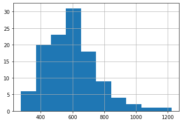

```python
punjab_newdf['ANNUAL'].hist()
```

You can see in the above data rainfall is looks close to normally distributed

Now lets try to find year when rainfall happens more than 1.5 times std deviation

```python
std_dev= punjab_newdf['ANNUAL'].std()
mean_punjab = punjab_newdf['ANNUAL'].mean()
print(std_dev)
```

```
163.35756776422343
```

```python
# df.loc[df['column_name'] == some_value]
selected_df_max = punjab_newdf.loc[punjab_newdf['ANNUAL'] > (mean_punjab + (std_dev*1.5))]
```

```python
selected_df_max.head(8)
```

|  | SUBDIVISION | YEAR | ANNUAL | deviation_from_mean |
| --- | --- | --- | --- | --- |
| 1480 | PUNJAB | 1909 | 846.1 | 252.564348 |
| 1488 | PUNJAB | 1917 | 1126.7 | 533.164348 |
| 1504 | PUNJAB | 1933 | 860.6 | 267.064348 |
| 1513 | PUNJAB | 1942 | 871.6 | 278.064348 |
| 1521 | PUNJAB | 1950 | 992.0 | 398.464348 |
| 1526 | PUNJAB | 1955 | 973.9 | 380.364348 |
| 1559 | PUNJAB | 1988 | 1222.6 | 629.064348 |
| 1566 | PUNJAB | 1995 | 869.1 | 275.564348 |

```python
selected_df_min = punjab_newdf.loc[punjab_newdf['ANNUAL'] < (mean_punjab - (std_dev*1.5))]
```

```python
selected_df_min.head()
```

|  | SUBDIVISION | YEAR | ANNUAL | deviation_from_mean |
| --- | --- | --- | --- | --- |
| 1489 | PUNJAB | 1918 | 339.6 | -253.935652 |
| 1573 | PUNJAB | 2002 | 274.7 | -318.835652 |

Excercise :

```
1.Find out states which have Highest Rainfall in the Year 2000 ?
2.Find out states which have lowest Rainfall in the year  2000?
3. Identify the min rain fall month and max rain fall month from the above state you have found?
```